# Auswertung V4

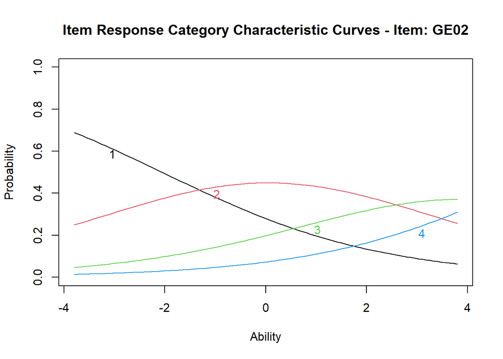

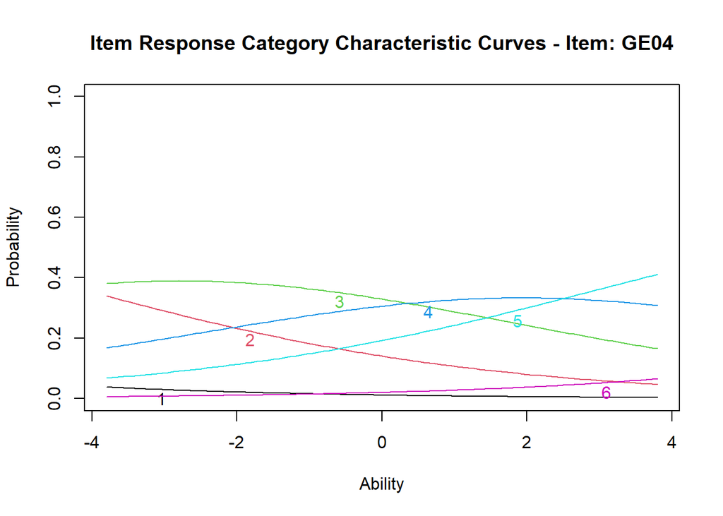

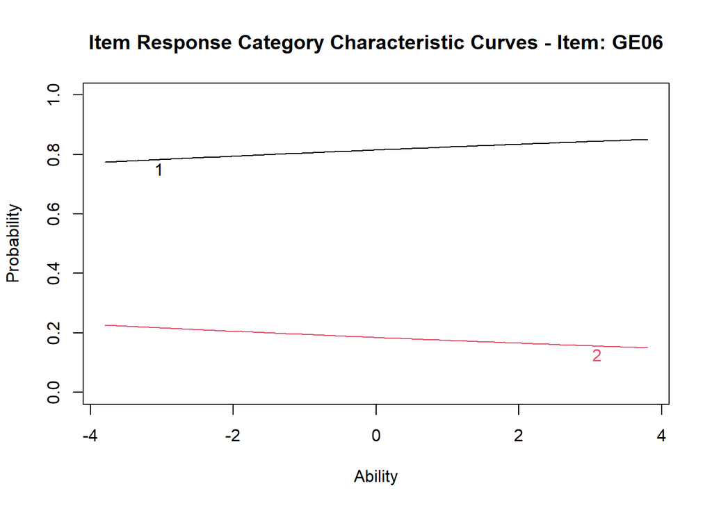

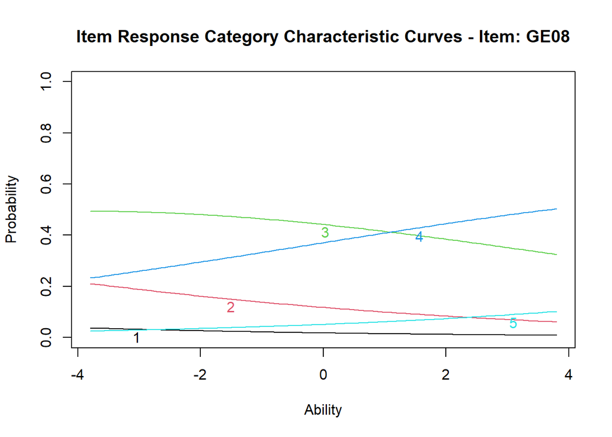

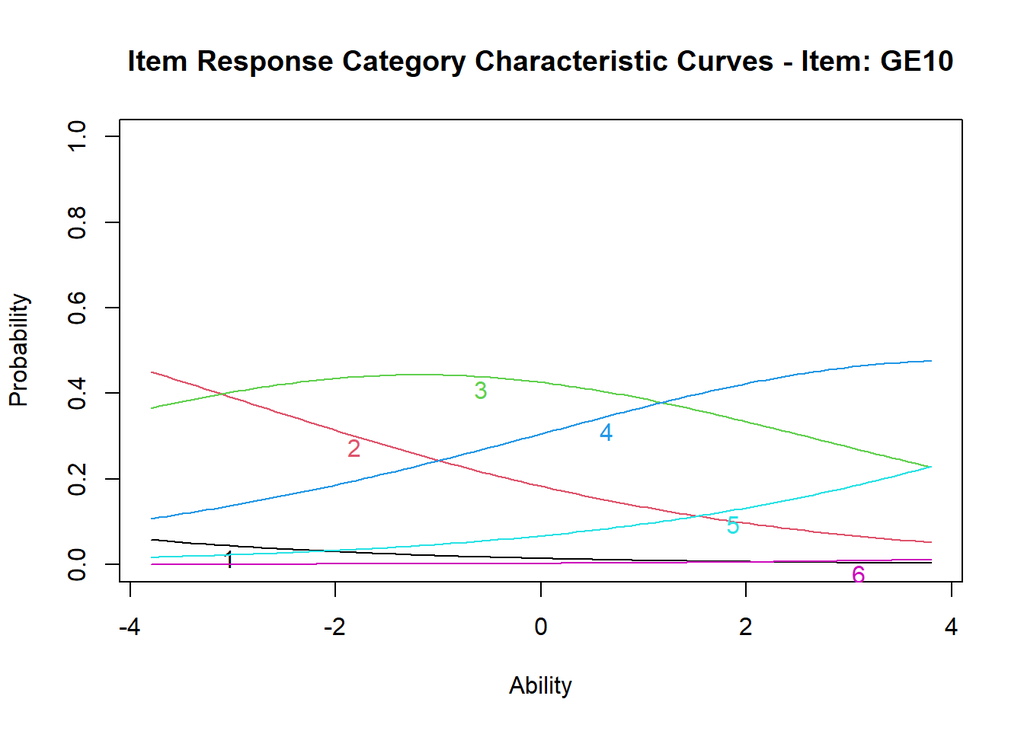

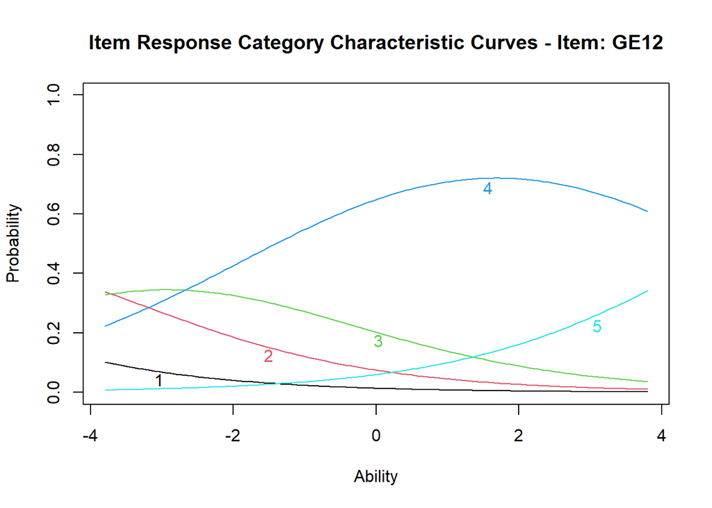

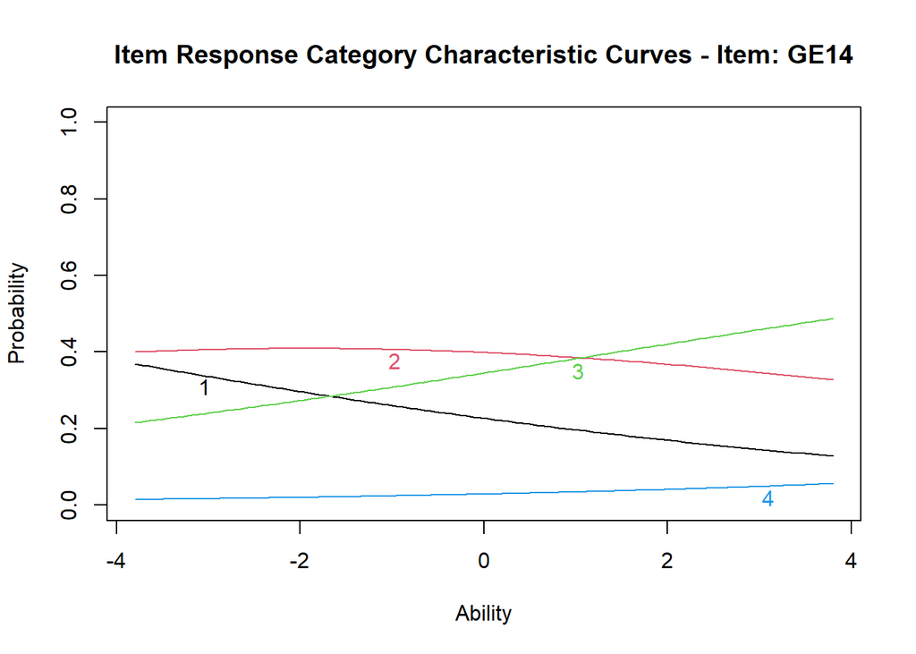

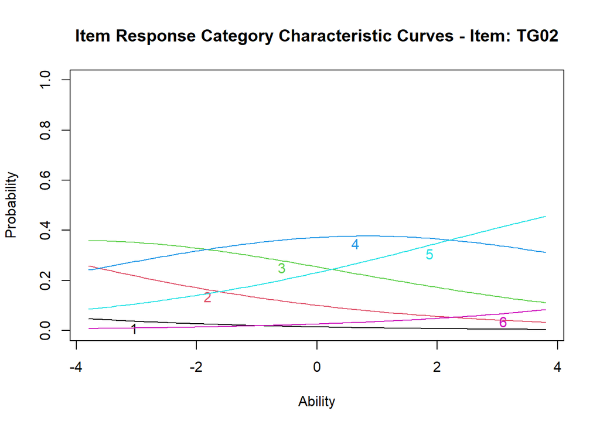

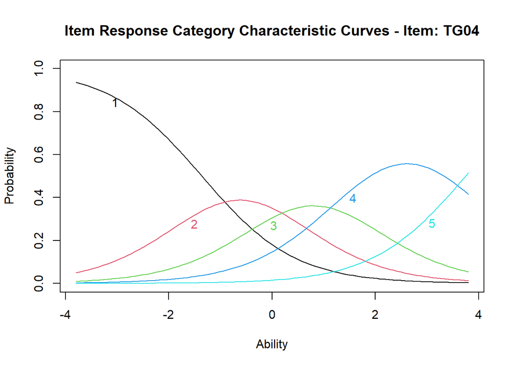

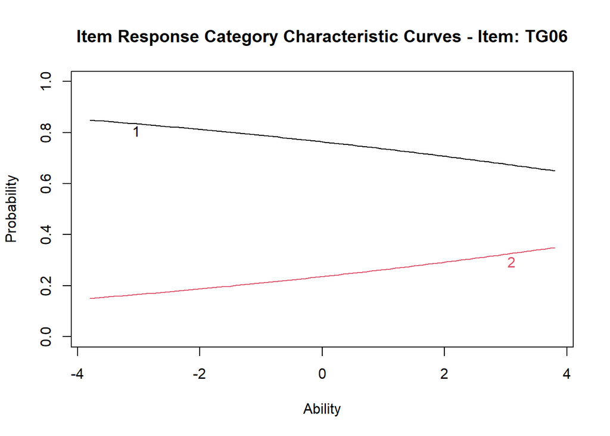

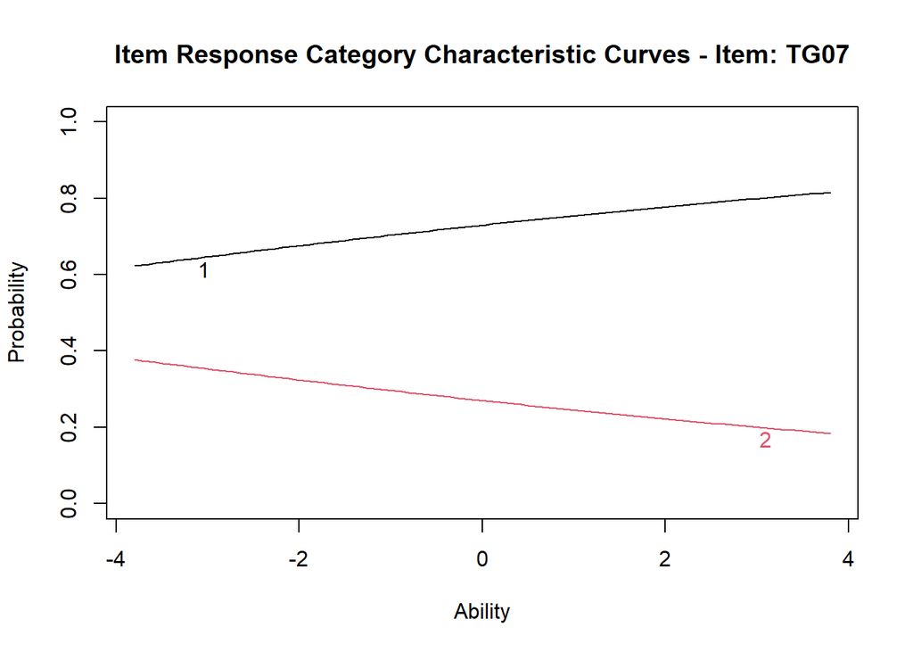

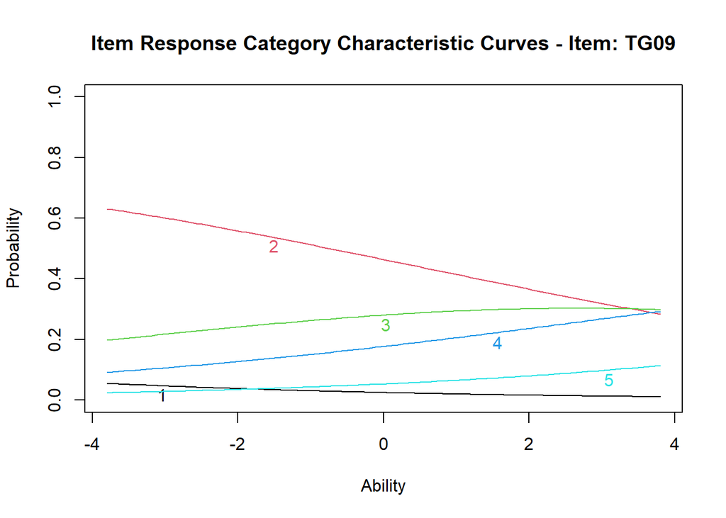

[3 more figures not shown]

```r
grm_summary <- summary(grm)
plot(grm, type = "ICC", ask = FALSE)
```

Leider bietet das `ltm`-package nicht die Möglichkeit das GRM Modell auf Itemfit zu überprüfen. Wir können aber schon an den ICC Kurven sehen, dass das Modell anscheinend nicht gut auf die Daten passt.

```r
print(paste("AIC:",grm_summary$AIC))
```

```
## [1] "AIC: 11078.8495638441"
```

```r
print(paste("BIC:",grm_summary$BIC))
```

```
## [1] "BIC: 11338.6152031081"
```

## GPCM

Wir können auch das Generalistierte PCM betrachten. Der Unterschied zum PCM ist, dass beim PCM angenommen wird, dass alle Items gleich gut zwischen guten und schlechten Schülern diskriminieren und zwar mit dem Wert $1$. Das GPCM geht nicht davon aus und schätzt entweder diesesn Diskriminerungswert aus den Daten, sodass er für alle Items $\neq 1$ sein kann oder es wird für jedes Item einzeln der Diskriminierungswert berechnet.

```r
gpcm_data <- data_score_standard

gpcm_rasch <- gpcm(gpcm_data, constraint="rasch")
# gpcm_factorscores <- factor.scores.gpcm(gpcm_rasch)
# plot.fscores(gpcm_factorscores, include.items = TRUE)
summary(gpcm_rasch)
```

```
##
## Call:
## gpcm(data = gpcm_data, constraint = "rasch")
##
## Model Summary:
##    log.Lik      AIC      BIC
##  -5614.203 11334.41 11536.87
##
## Coefficients:
## $GE02
##          value std.err z.value
## Catgr.1 -0.551   0.146  -3.771
## Catgr.2  0.871   0.162   5.388
## Catgr.3  1.290   0.244   5.290
## Dscrmn   1.000      NA      NA
##
## $GE04
##          value std.err z.value
## Catgr.1 -2.965   0.526  -5.632
## Catgr.2 -1.067   0.185  -5.754
## Catgr.3  0.049   0.152   0.324
## Catgr.4  0.627   0.173   3.617
## Catgr.5  2.689   0.409   6.574
## Dscrmn   1.000      NA      NA
##
## $GE06
##         value std.err z.value
## Catgr.1 1.563   0.156  10.022
## Dscrmn  1.000      NA      NA
##
## $GE08
##          value std.err z.value
## Catgr.1 -2.322   0.446  -5.211
## Catgr.2 -1.518   0.192  -7.915
## Catgr.3  0.201   0.138   1.454
## Catgr.4  2.262   0.270   8.386
## Dscrmn   1.000      NA      NA
##
## $GE10
##          value std.err z.value
```

[output cut: 76 more lines]

```
## Catgr.1 -2.785   0.475  -5.866
## Catgr.2 -0.953   0.181  -5.268
## Catgr.3 -0.056   0.147  -0.380
## Catgr.4  1.987   0.248   8.004
## Dscrmn   1.000      NA      NA
##
##
## Integration:
## method: Gauss-Hermite
## quadrature points: 21
##
## Optimization:
## Convergence: 0
## max(|grad|): 0.0067
## optimizer: nlminb
```

```r
gpcm <- gpcm(gpcm_data, constraint="gpcm")
summary(gpcm)
```

```
##
## Call:
## gpcm(data = gpcm_data, constraint = "gpcm")
##
## Model Summary:
##    log.Lik      AIC      BIC
##  -5466.878 11069.76 11329.52
##
## Coefficients:
## $GE02
##          value std.err z.value
## Catgr.1 -1.780   1.022  -1.742
## Catgr.2  3.278   1.869   1.754
## Catgr.3  4.150   2.214   1.874
## Dscrmn   0.245   0.140   1.750
##
## $GE04
##          value std.err z.value
## Catgr.1 -8.708   4.420  -1.970
## Catgr.2 -2.904   1.342  -2.164
## Catgr.3  0.244   0.477   0.511
## Catgr.4  1.645   0.803   2.049
## Catgr.5  7.707   3.737   2.062
## Dscrmn   0.313   0.163   1.923
##
## $GE06
##         value std.err z.value
## Catgr.1 8.267   4.895   1.689
## Dscrmn  0.179   0.107   1.671
##
## $GE08
##          value std.err z.value
## Catgr.1 -7.130   3.413  -2.089
## Catgr.2 -4.831   2.234  -2.163
## Catgr.3  0.668   0.528   1.264
## Catgr.4  7.281   3.375   2.157
## Dscrmn   0.283   0.137   2.059
##
## $GE10
##          value std.err z.value
```

[output cut: 76 more lines]

```
## Catgr.1 -8.720   4.123  -2.115
## Catgr.2 -2.809   1.287  -2.183
## Catgr.3 -0.216   0.490  -0.440
## Catgr.4  6.318   2.874   2.198
## Dscrmn   0.287   0.138   2.086
##
##
## Integration:
## method: Gauss-Hermite
## quadrature points: 21
##
## Optimization:
## Convergence: 1
## max(|grad|): 0.41
## optimizer: nlminb
```

```r
# rm <- RM(rasch_data)
# summary(rm)
# plotICC(rm)
# plotjointICC(rm)
# plotPImap(rm, 27:54, sorted = FALSE)
# plotPWmap(rm, itemCI = list())
#
# print(coef(rm, parm = "eta"))
#
# lrt_result <- LRtest(rm, PC_model)
# print(lrt_result)
```

# Analysen der Fragen

Hier wollen wir nun mithilfe deskriptiver Daten und unserer IRT Analyse die Fragen analysieren und gegebenefalls verbessern. Fangen wir mit der Itemschwierigkeit an.

## Itemschwierigkeit

Schauen wir uns erst einmal an, welche durschnittliche Punktzahl bei den Fragen erreicht wurden. Da in denen einzelnen Fragen unterschiedliche viele Punkte erreichbar sind, geben wir diese im Verhältnis zur maximal erreichbaren Punktzahl in jeder Frage an.

$$average\:score=\frac{mean_{Score}}{max_{points}}$$

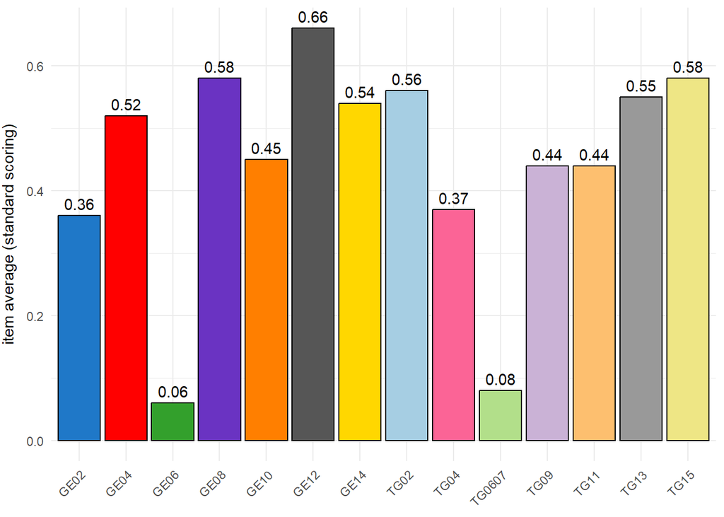

```r
max_points <- c(lengths(glossar_mc),unlist(glossar_sc))

item_average_standard <- question_scores %>%
  summarise(across(ends_with("Score_Standard"),~ mean(.x, na.rm = TRUE))) %>%
  pivot_longer(everything(),names_to = "frage", values_to = "average") %>%
  mutate(max_points = max_points[fragenkürzel_gesamt])

#Zeilen für GE06_Score und GE07_Score zusammenfassen
item_average_standard <- item_average_standard %>%
  mutate(frage=ifelse(frage %in% c("TG06_Score_Standard", "TG07_Score_Standard"),"TG0607_Score_Standard", frage)) %>%
  group_by(frage) %>%
  summarise(
    average = sum(average,na.rm = T),
    max_points = sum(max_points,na.rm = T)
  ) %>%
  ungroup()

#Prozentsatz berechnen und cleanen
item_average_standard <- item_average_standard %>%
  mutate(avrg_percentage = average/max_points) %>%
  mutate(scoring = "Standard") %>%
  mutate_if(is.numeric, round, digits = 2) %>%
  mutate(frage=str_remove(frage,fixed("_Score_Standard")))
  #mutate(frage=fct_reorder(frage,avrg_percentage))

mycolors <- unname(cols25())
ggplot(item_average_standard,aes(x=frage,y=avrg_percentage, fill=frage))+
  geom_bar(color = "black", stat = "identity") +
  #scale_fill_brewer(palette = "PuBu") +
  geom_text(aes(label=avrg_percentage),vjust=-0.5) +
  scale_fill_manual(values=mycolors) +
  theme_minimal()+
  theme(axis.text.x = element_text(angle = 45, hjust = 1),
        axis.title.x = element_blank(),
        axis.title.y = element_text(vjust = 3)) +
  guides(fill="none") +
  labs(y="item average (standard scoring)")
```

Wir sehen, dass sich die erreichten Punktzahlen um die $50\%$ Marke verteilen. Das ist erst einmal nicht verwunderlich, da fast jeder Punkt mit einer Chance $50\%$ erreicht werden kann (Aussage ist entweder wahr oder falsch). Teilweise fällt uns auf, dass die Wahrscheinlichkeiten sogar unter den erwarteten $50\%$ sind. Andersherum gibt es auch Fragen welche besser als durch Raten beantwortet wurden. Schauen wir uns doch einmal an, wie oft bei jeder Frage, das *richtige* Statement auch korrekt als wahr identifiziert wurde.

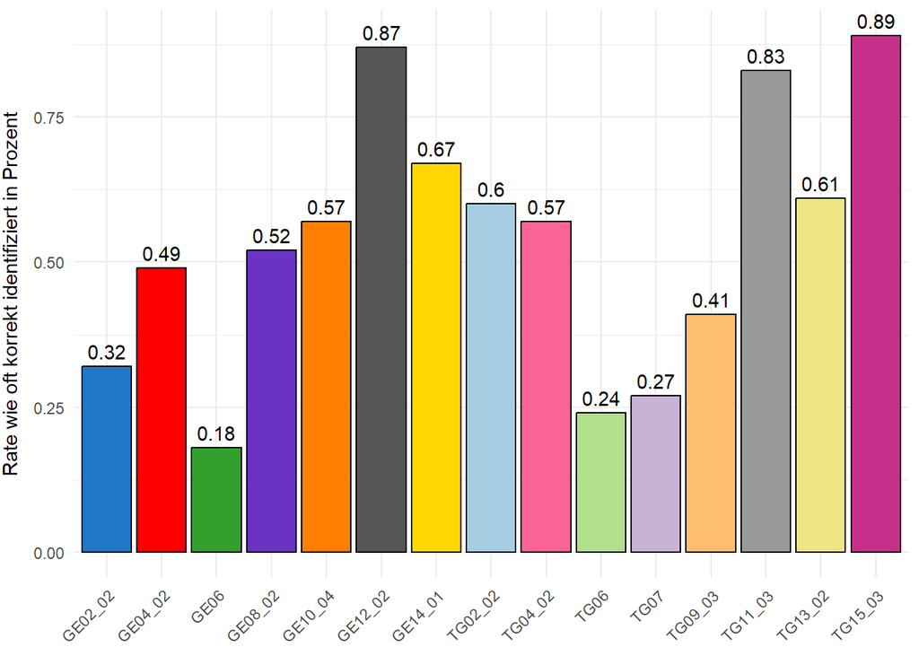

```r
true_statements <- fragenkürzel_sc
for (question in fragenkürzel_mc){
  statements <- glossar_mc[[question]]
  indices <- which(statements == 1)
  true_statements <- c(true_statements,paste0(question, sprintf("_%02d", indices)))
}


true_statments_average <- data_score_raw %>%
  select(all_of(true_statements)) %>%
  summarise(across(everything(),~ mean(.x, na.rm = TRUE))) %>%
  pivot_longer(everything(),names_to = "frage", values_to = "average") %>%
  mutate_if(is.numeric, round, digits = 2)

mycolors <- unname(cols25())
ggplot(true_statments_average,aes(x=frage,y=average, fill=frage))+
  geom_bar(color = "black", stat = "identity") +
  #scale_fill_brewer(palette = "PuBu") +
  geom_text(aes(label=average),vjust=-0.5) +
  scale_fill_manual(values=mycolors) +
  theme_minimal()+
  theme(axis.text.x = element_text(angle = 45, hjust = 1),
        axis.title.x = element_blank(),
        axis.title.y = element_text(vjust = 3)) +
  guides(fill="none") +
  labs(y="Rate wie oft korrekt identifiziert in Prozent")
```

Wir können interessanterweise feststellen, dass bei manchen Fragen die Lösungswahrscheinlichkeit unter der Ratewahrscheinlichkeit liegt (zum Beispiel GE02 oder TG09), aber auch - und das ist sehr interessant - weit über der Ratewahrscheinlichkeit wie zum Beispiel bei GE12_02, TG11_03 oder TG15_03. Dies ist auf jeden Fall eine Bestätigung dafür, dass wir ein Multiple Choice Format gewählt haben.

## Antwortverteilungen

Nachdem wir uns die Gesamtscores angeschaut haben, wollen wir nun die Fragen im Einzelnen betrachten. Hier interessieren uns vor allem die Verteilung der Antworten.

### Gesichtserkennung

#### Modellbildung

[output not shown]

```r
generate_statistics("GE02")
```

| Frage | average | avrg_percentage | max_points |
| --- | --- | --- | --- |
| GE02 | 1.07 | 0.36 | 3 |

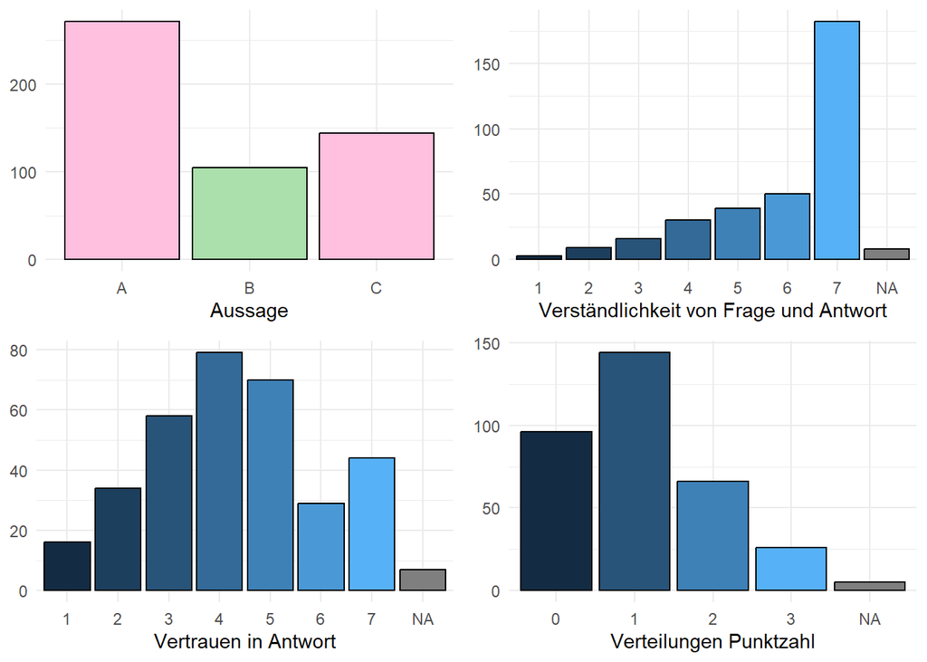

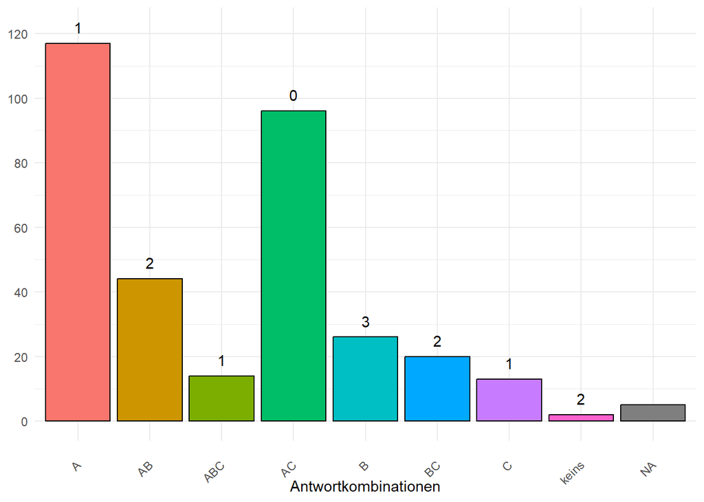

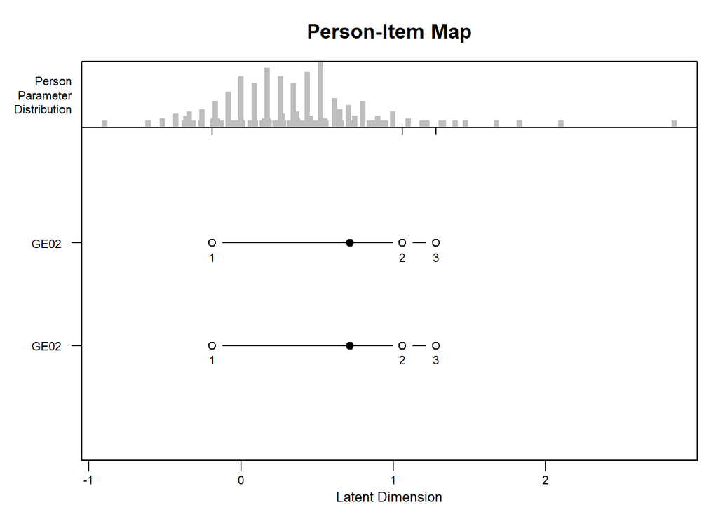

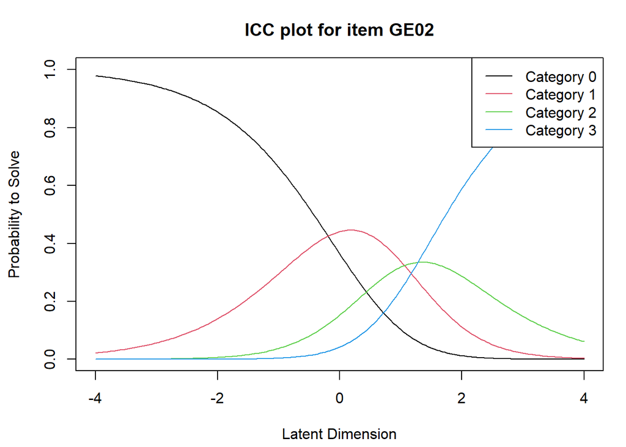

**Inhalt:**

- Frage funktioniert gut. Die Schwelle zwischen 1 und 2 Punkte ist etwas weit, lässt sich aber wahrscheinlich schlecht ändern.
- Erreichte Punktzahl i. O.

**Verständnis**

- Wird als sehr verständlich empfunden

#### Datenauswahl

**Datenauswahl**

Die für den ML-Prozess nötigen Daten müssen in einer ausreichenden Menge vorliegen, um daraus statistische Zusammenhänge schließen zu können. Die Entwickler sammeln dazu die benötigten Daten (Messungen, Webcrawler, …) oder, im Fall von verstärkendem Lernen, definieren, welche Daten der Agent erheben und verarbeiten soll. Die Auswahl und Bewertung der benötigten Daten erfolgt demnach durch die Entwickler.

| Frage | average | avrg_percentage | max_points |
| --- | --- | --- | --- |
| GE04 | 2.58 | 0.52 | 5 |

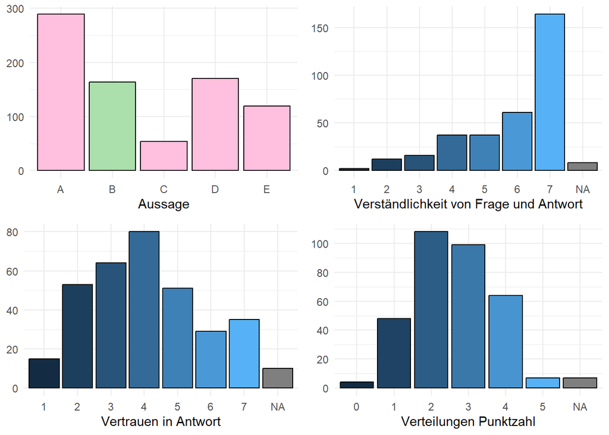

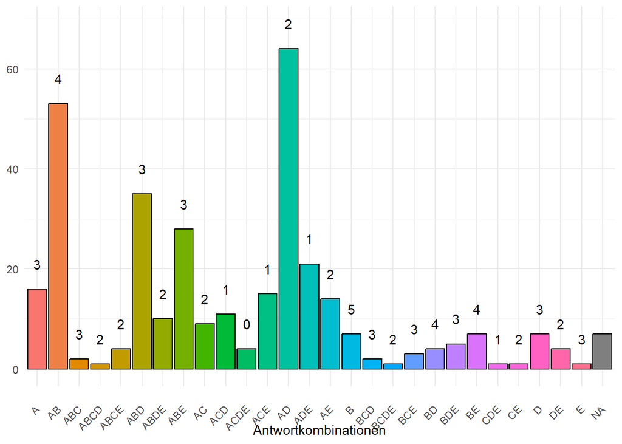

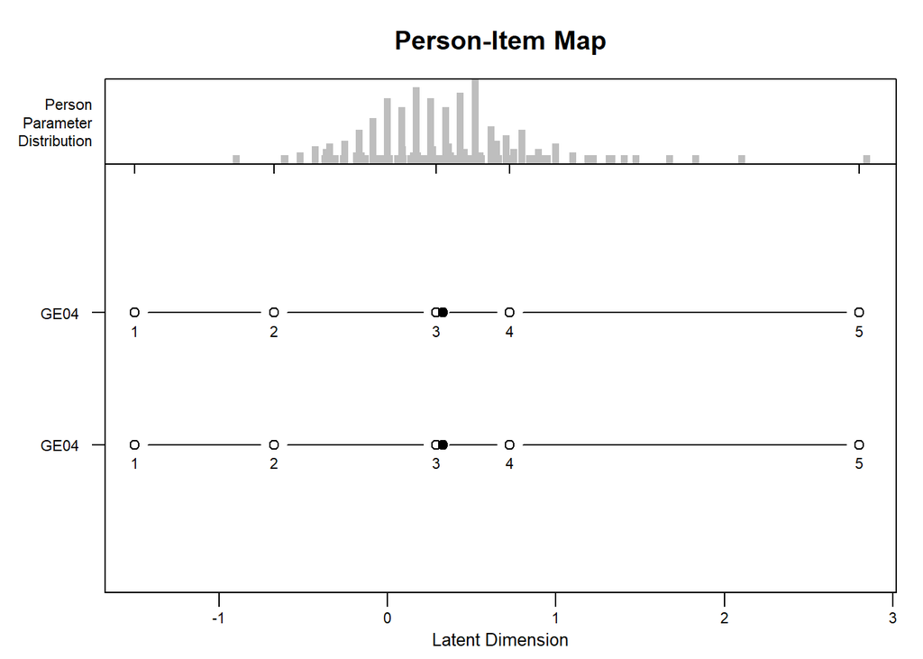

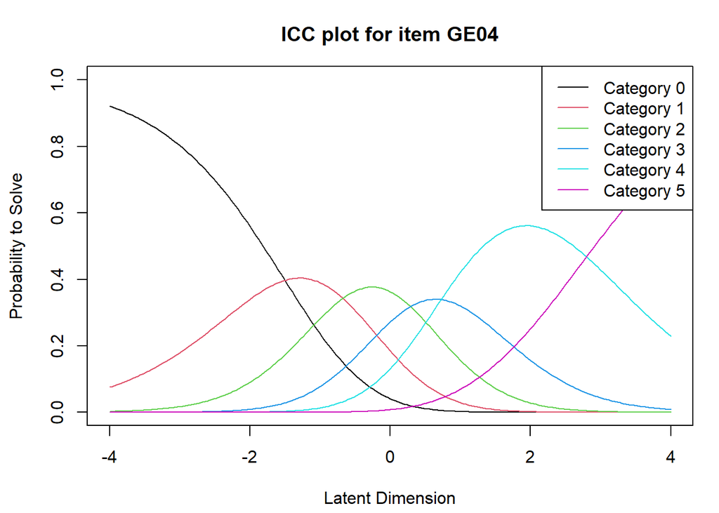

**Inhalt:**

- Schwelle 1 und eventuell auch 2 zu leicht. Man könnte Aussage C weglassen, weil diese auch kaum als korrekt identifiziert wurde und dafür sorgt, dass man direkt einen Punkt erhält.
- Alle anderen Optionen wurden oft genug gewählt.
- Insgesamt eine etwas leichtere Fragen, vor allem, wenn man weiß/lernt, dass Option A falsch ist -> hier sind starke Verbesserungen erwartbar.

**Verständnis**

- Wird als sehr verständlich empfunden

#### Statistische Modelle

[output not shown]

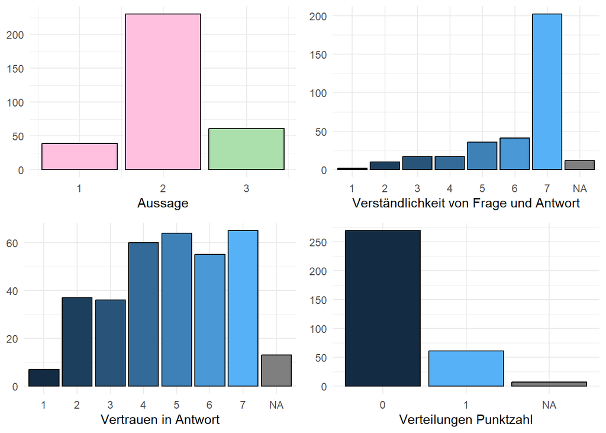

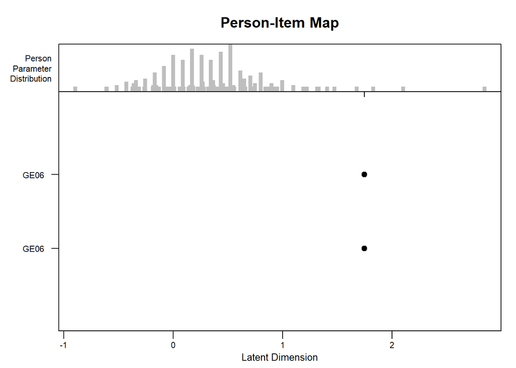

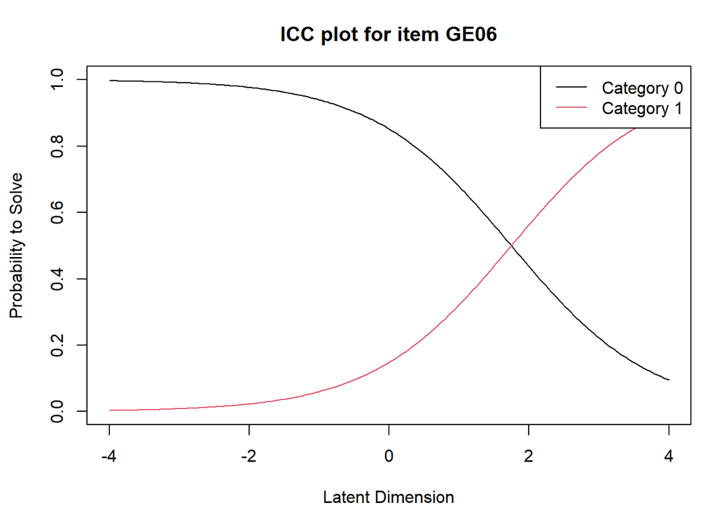

**Inhalt:**

- Schwere Frage
- Option 1 wird kaum gewählt, aber ist irgendwie für den Aufbau der Frage

**Verständnis**

- Wird als sehr verständlich empfunden

#### Zeitpunkt

[output not shown]

| Frage | average | avrg_percentage | max_points |
| --- | --- | --- | --- |
| GE08 | 2.32 | 0.58 | 4 |

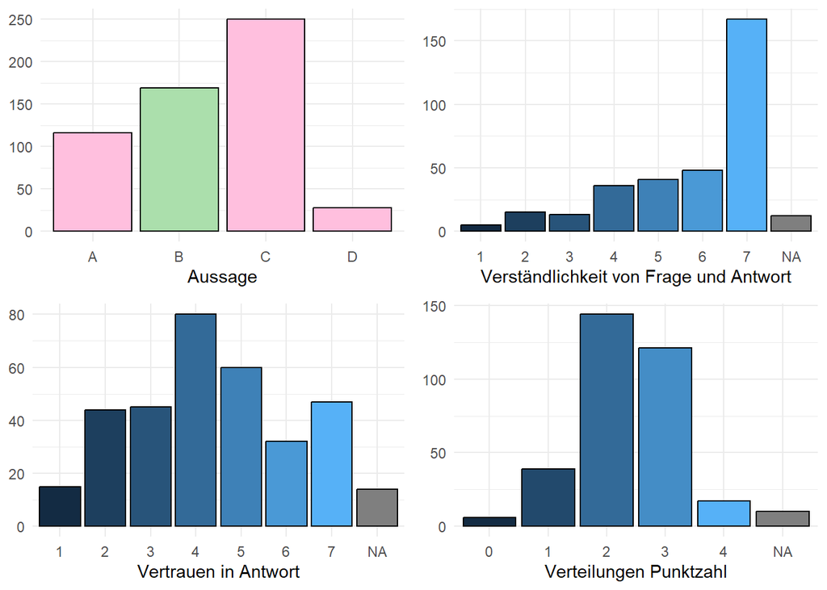

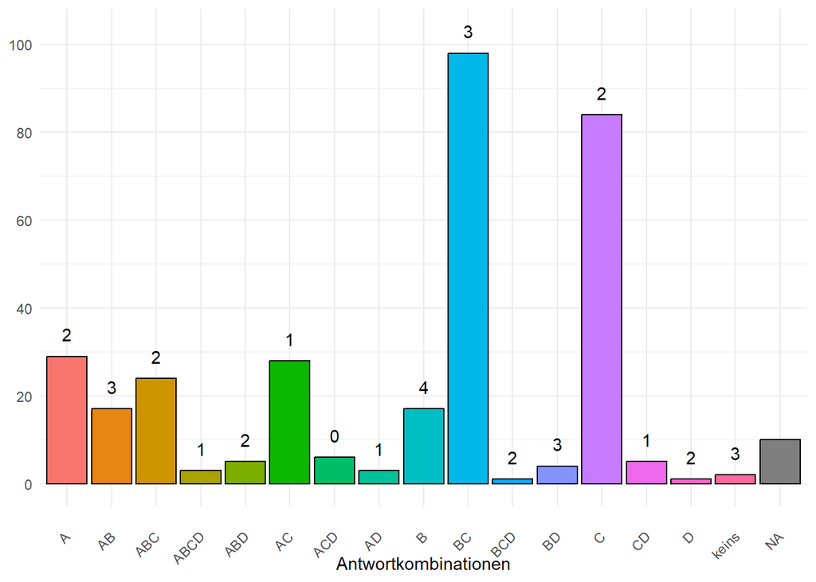

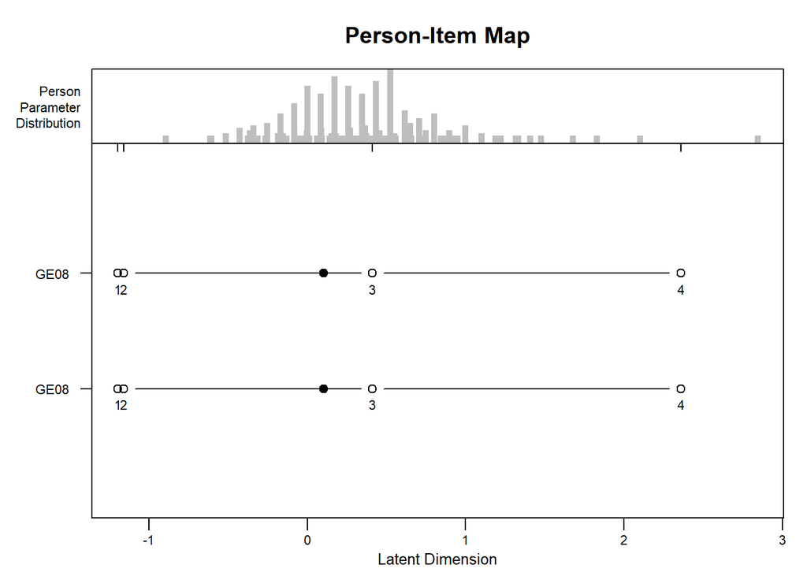

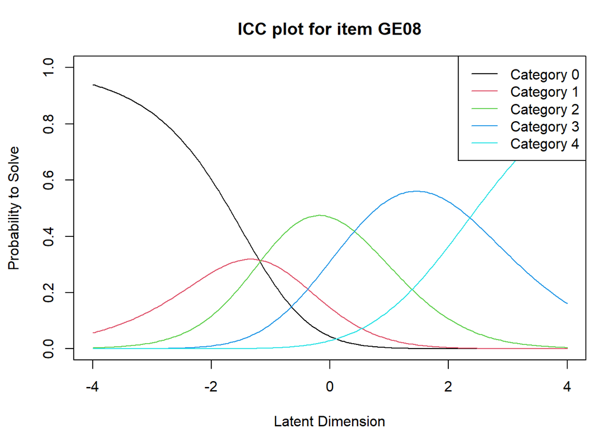

**Inhalt:**

- Schwelle zwischen 1 und 2 viel zu nah. Liegt höchstwahrscheinlich an D, weil das niemand nimmt und somit mindestens einen Punkt bekommt.
- Entfernt man die letzte Option, wäre dieses Item relativ leicht

**Verständnis**

- Wird als sehr verständlich empfunden

#### Programmierung

| **Programmierung** | Die Entwickler programmieren die Struktur und die Art des Trainings. Dazu zählen die Modellstruktur und das Lernverfahren. Nicht programmiert werden die Verarbeitungsregeln des Modells. |
| --- | --- |

| Frage | average | avrg_percentage | max_points |
| --- | --- | --- | --- |
| GE10 | 2.24 | 0.45 | 5 |

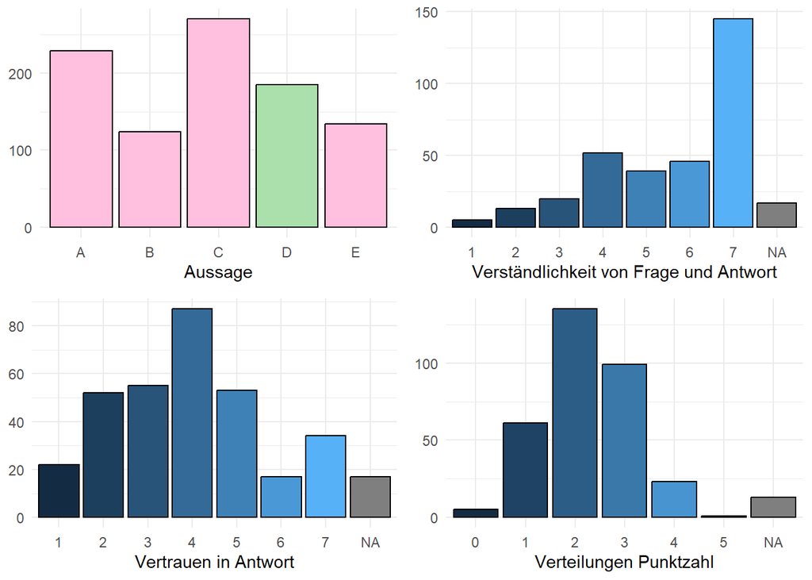

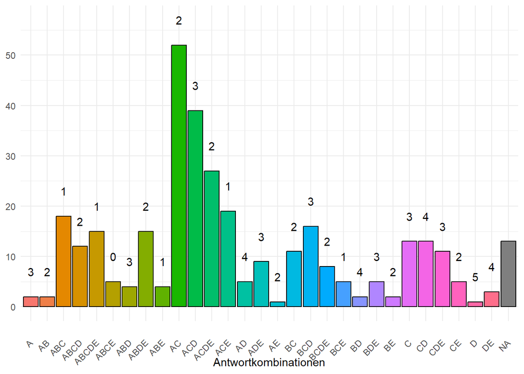

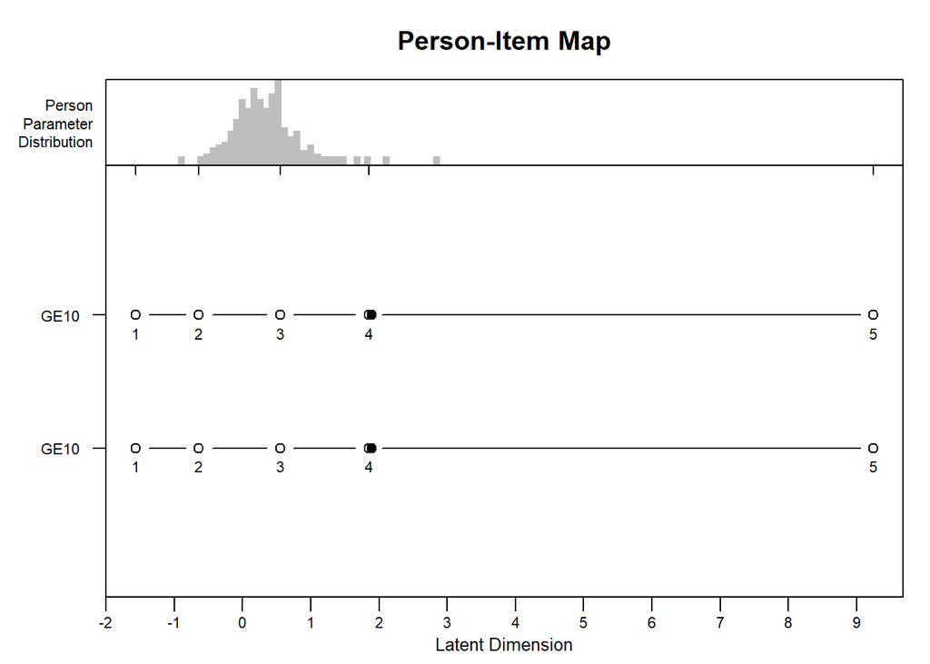

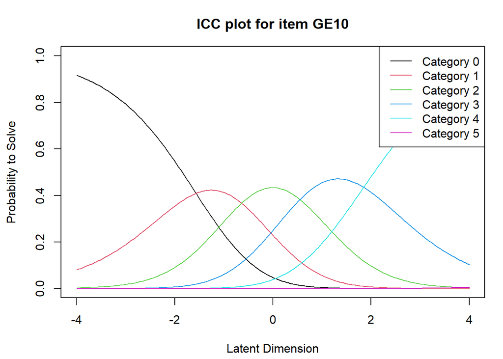

- **Inhalt:**
  - Schwelle zwischen 4 und 5 viel zu schwer. Gleichzeitig Schwelle 1 viel zu leicht. Das heißt: es ist viel zu leicht einen Punkt zu erhalten und viel zu schwer alle Punkte zu erreichen.
  - Da es keine Option gibt, die sehr selten genommen wird, muss die leichte erste Schwelle daran liegen, dass verschiedene Kombinationen gewählt werden, bei der dann immer mindestens ein Statement frei bleibt, welches falsch ist.
  - Das zeigt sich auch in der sehr großen Varianz der Antwortkombinationen.
  - Auch ist die Frage (im Vergleich) mehr als unverständlich deklariert.
  - Die Frage hatte auch bei den Experten Probleme verursacht. Es scheint, dass sie nicht eindeutig zu beantworten ist.
  - **Raus?**

  **Verständnis**
  - Wird größtenteils als verständlich empfunden

#### Evaluation

| **Evaluation** | Die im ML-Prozess entstehenden Modelle müssen von den Entwicklern mittels verschiedener Metriken getestet werden. Diese Metriken bewerten die Ausgaben der trainierten Modelle. Die Regeln, nach denen d… |
| --- | --- |

[figure not shown]

| Frage | average | avrg_percentage | max_points |
| --- | --- | --- | --- |
| GE12 | 2.65 | 0.66 | 4 |

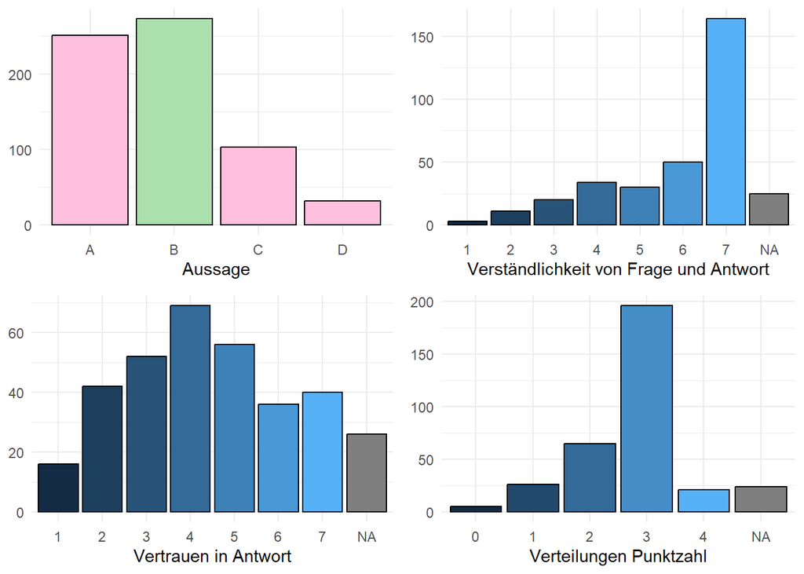

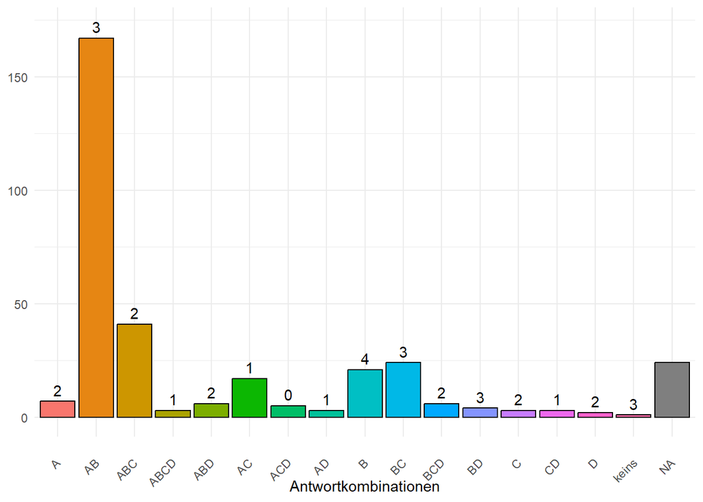

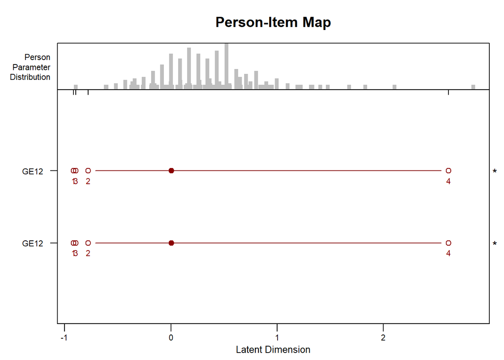

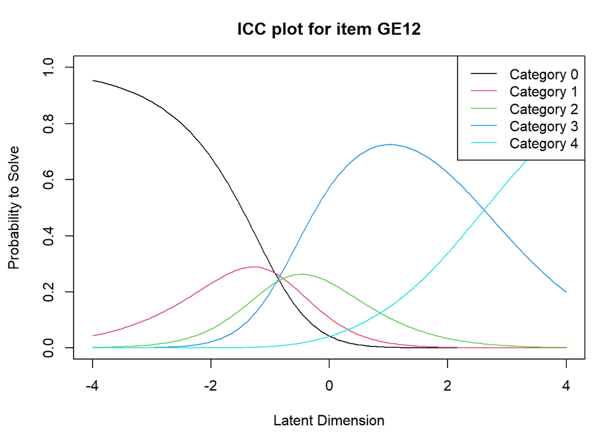

  **Verständnis**
  - Wird als sehr verständlich empfunden

#### Datenqualität

| **Datenqualität** | Die Trainingsdaten müssen in erster Linie das zu lösende Problem beschreiben. Beispielsweise sollten die Daten mit der gewählten Zielvariable korrelieren. Die Daten sollten darüber hinaus auf etwaige … |
| --- | --- |

[figure not shown]

| Frage | average | avrg_percentage | max_points |
| --- | --- | --- | --- |
| GE14 | 2.17 | 0.54 | 4 |

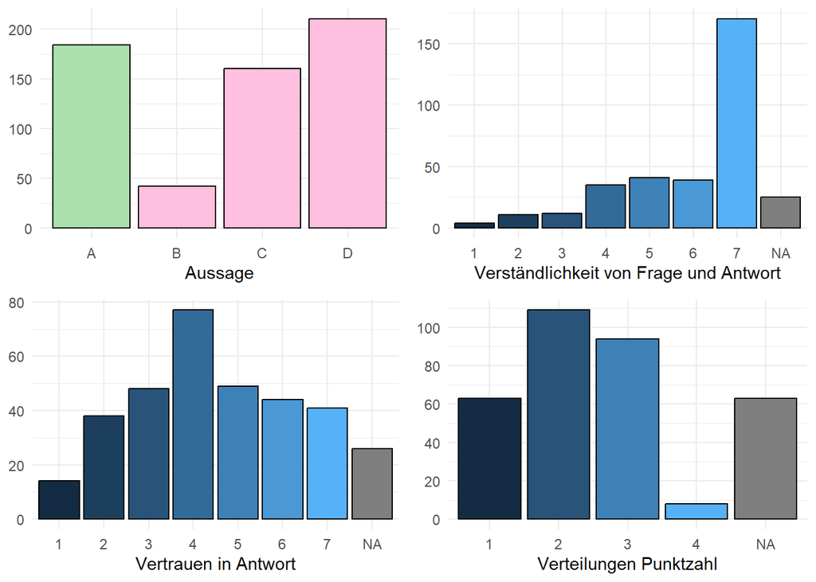

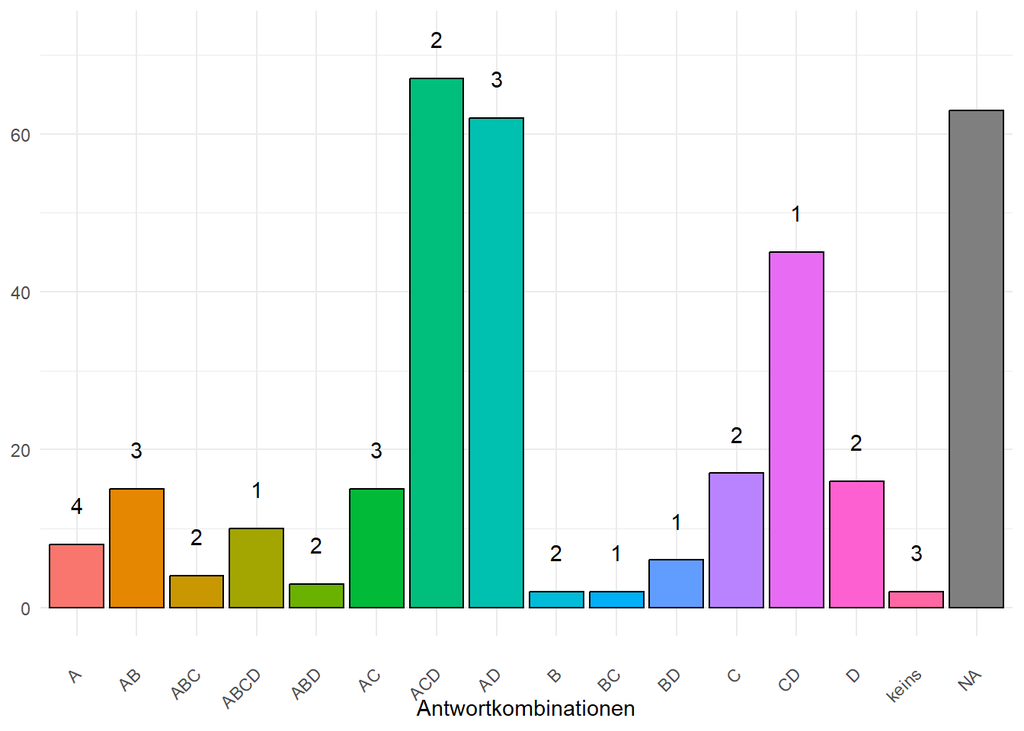

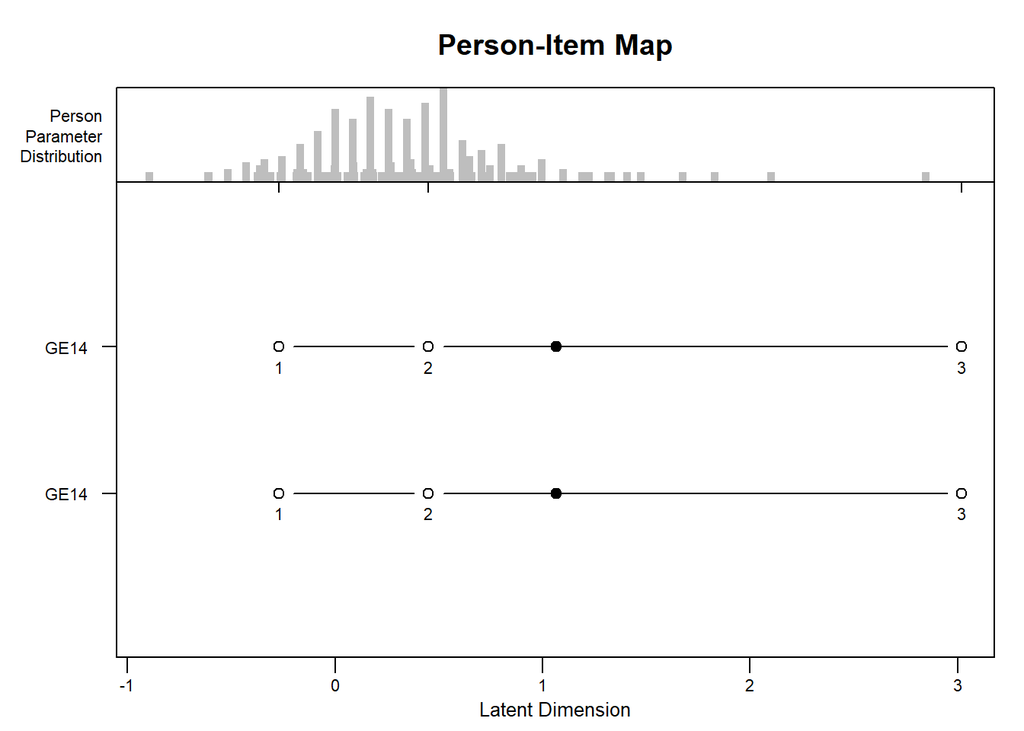

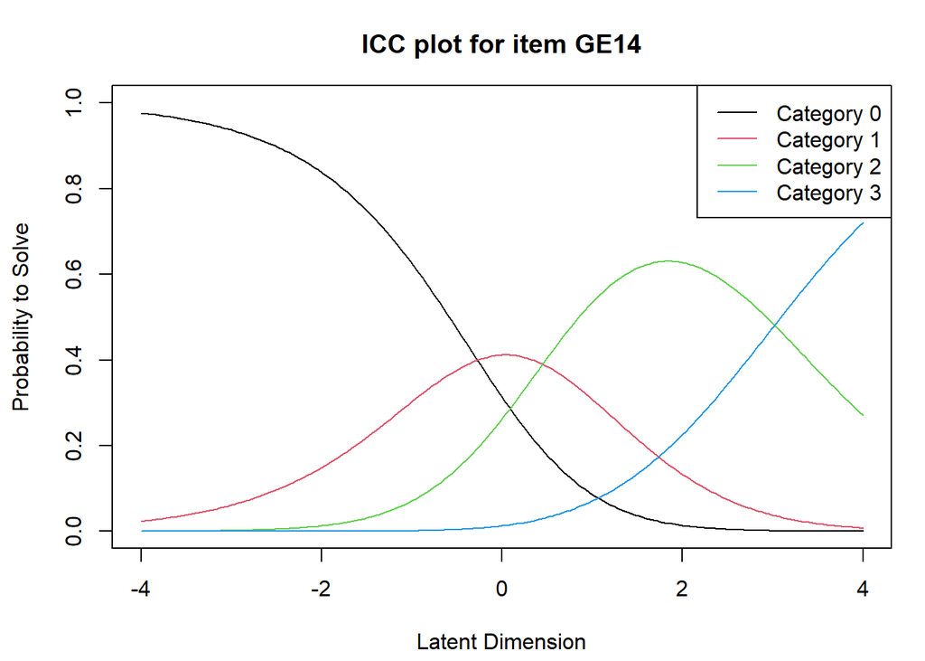

- **Inhalt:**
  - Das ist die neue Frage
  - Schwellenverteilung ist eigentlich gut, nur dass die vierte zu schwer ist, was wahrscheinlich an Option D liegt, die ein starker Distraktor ist
  - Option B ist schon die schwerere Variante als die Comiczeichnungen und wurde dennoch kaum gewählt.
  - Es ist etwas verwunderlich, dass die Schwellen 1 und 2 vergleichsweise so schwer eingeschätzt werden, wenn im Mittel aber 2 Punkte erziehlt werden.

  **Verständnis**
  - Wird als sehr verständlich empfunden

### Textgenerierung

#### Datenauswahl

**Datenauswahl**

Die für den ML-Prozess nötigen Daten müssen in einer ausreichenden Menge vorliegen, um daraus statistische Zusammenhänge schließen zu können. Die Entwickler sammeln dazu die benötigten Daten (Messungen, Webcrawler, …) oder, im Fall von verstärkendem Lernen, definieren, welche Daten der Agent erheben und verarbeiten soll. Die Auswahl und Bewertung der benötigten Daten erfolgt demnach durch die Entwickler.

[figure not shown]

| Frage | average | avrg_percentage | max_points |
| --- | --- | --- | --- |
| TG02 | 2.78 | 0.56 | 5 |

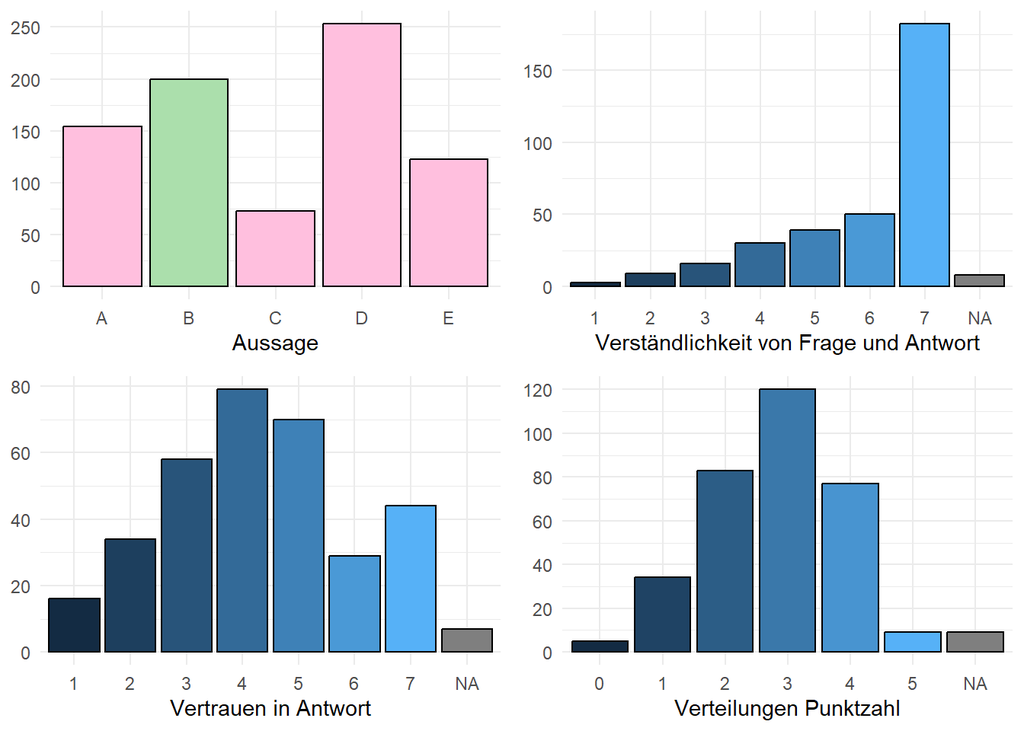

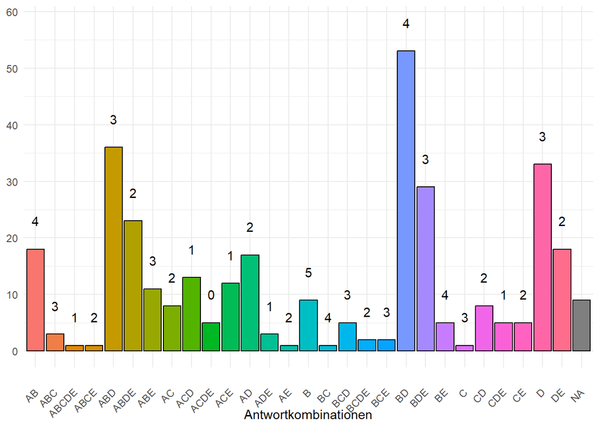

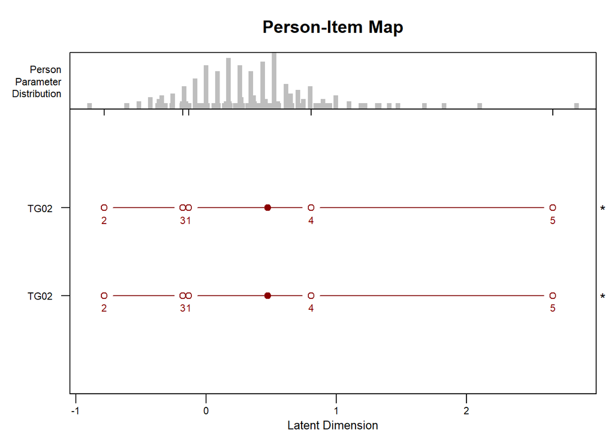

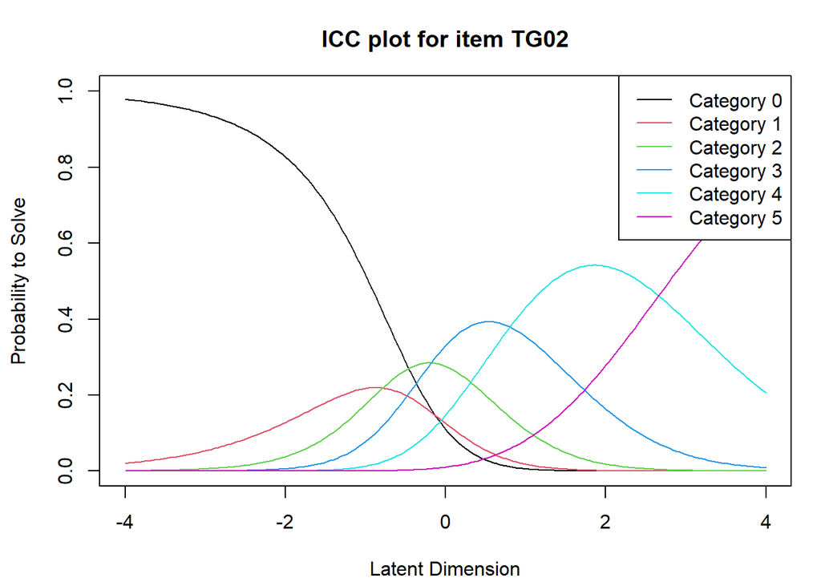

- **Achtung:** Hier ist die Reihenfolge der Aussagen in dem Fragebogen vertauscht. Die Reihenfolge der Fragen ist: A,D,B,C,E
- **Inhalt:**
  - Diese Frage ist schwer zu evaluieren
  - Die Schwellen 1,2,3 sind vertauscht, das heißt die Frage müsste angepasst werden
  - Gleichzeitig sind alle Optionen relativ oft vertreten (`>10\%`), sodass nicht einfach eine entfernt werden kann
  - Der Grund warum hier eher mehr Punkte erreicht werden, ist, dass unterschiedliche Fehlvorstellungen gleichzeitig abgefragt werden und die Befragten nicht alle FV teilen müssen und somit Punkte erhalten
    - zum Beispiel bei öfteste Option BD –> FV Autonomous Data Aquuisition, aber nicht Programmierung
  - Entweder Zusammenfassen von Optionen oder Aufteilen der Frage

  **Verständnis**
  - Wird als sehr verständlich empfunden

#### Modellbildung

| **Modellbildung** | Im ML-Prozess wird aus Daten ein Modell gebildet, welches diese Daten beschreibt. Die Regeln zur Verarbeitung der Daten sind in diesem Modell enthalten und werden durch den ML-Prozess automatisiert er… |
| --- | --- |

[figure not shown]

| Frage | average | avrg_percentage | max_points |
| --- | --- | --- | --- |
| TG04 | 1.46 | 0.37 | 4 |

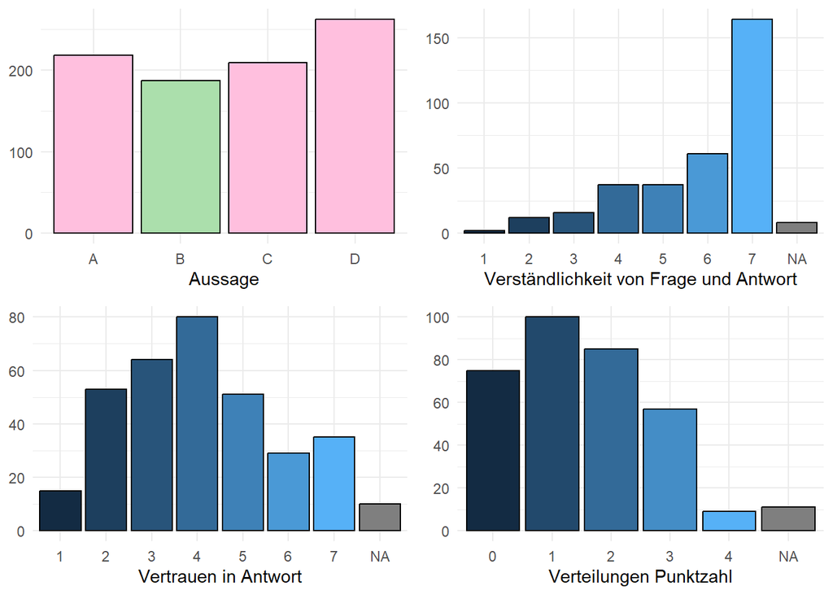

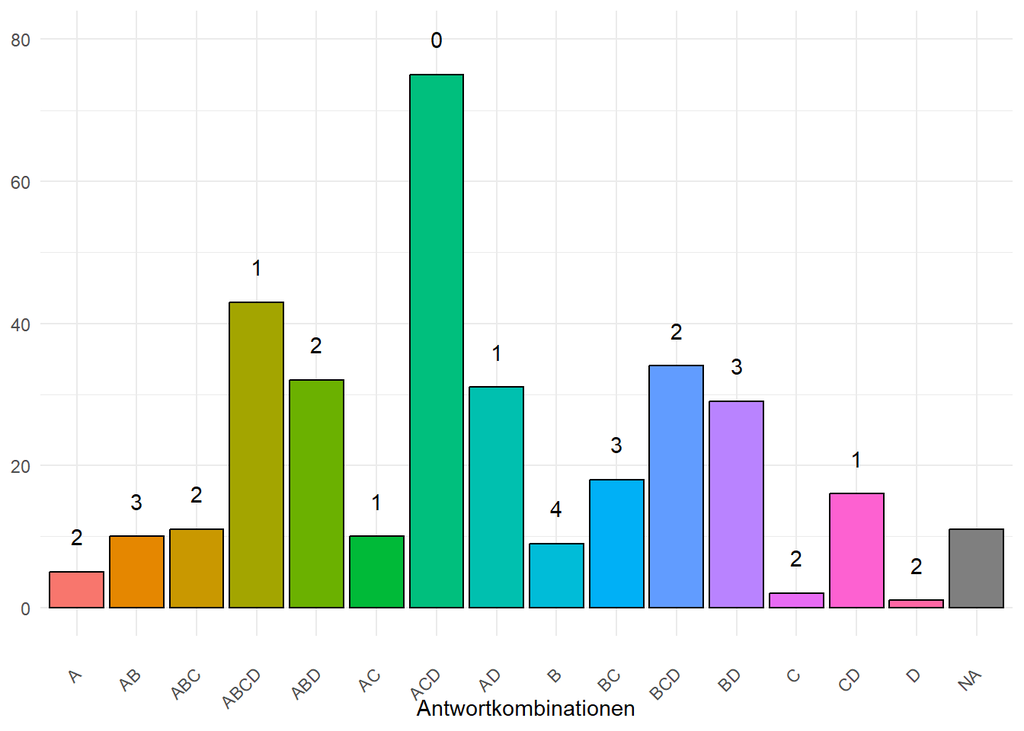

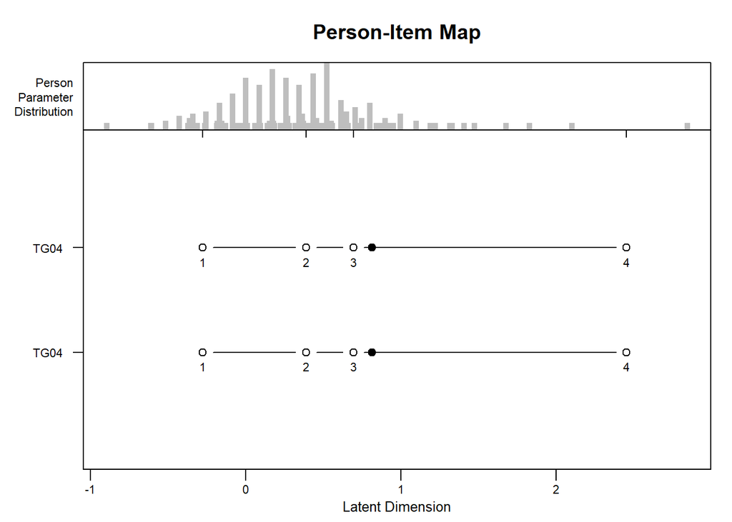

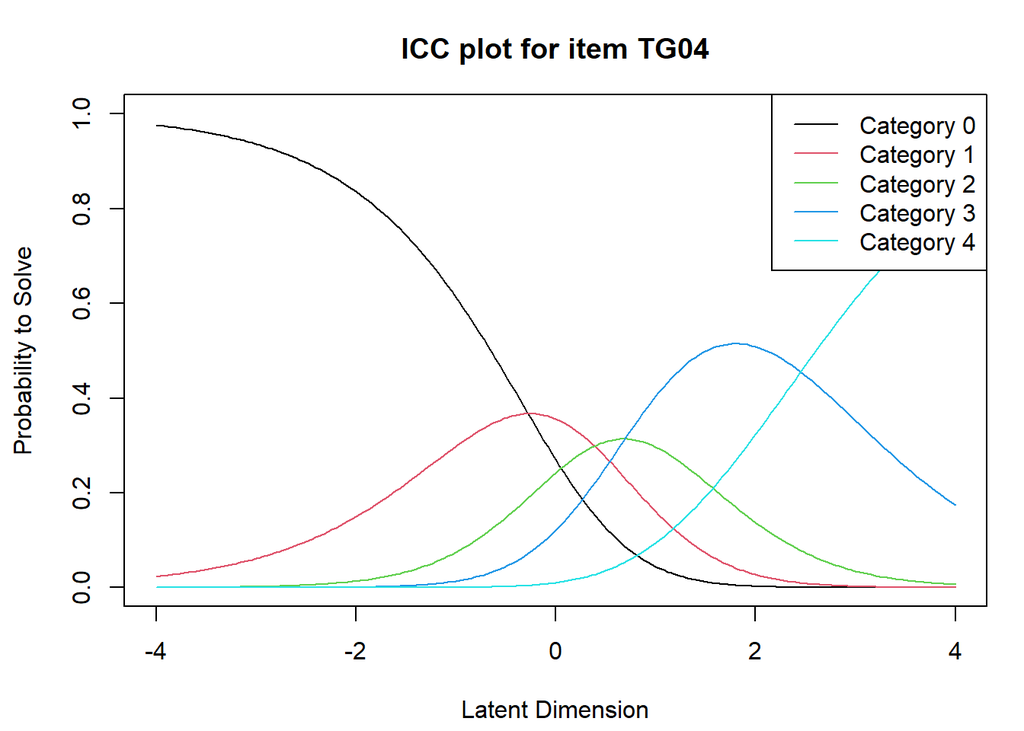

- **Inhalt:**
  - Gute Frage

  **Verständnis**
  - Wird als sehr verständlich empfunden

#### Statistische Modelle

| **Statistische Modelle** | Die Ergebnisse des ML Prozesses sind statistische Modelle. Folglich basieren die Ausgaben dieser Modelle auf Wahrscheinlichkeiten. ML Anwendungen entscheiden daher nicht mit genauer Exaktheit, sondern… |
| --- | --- |

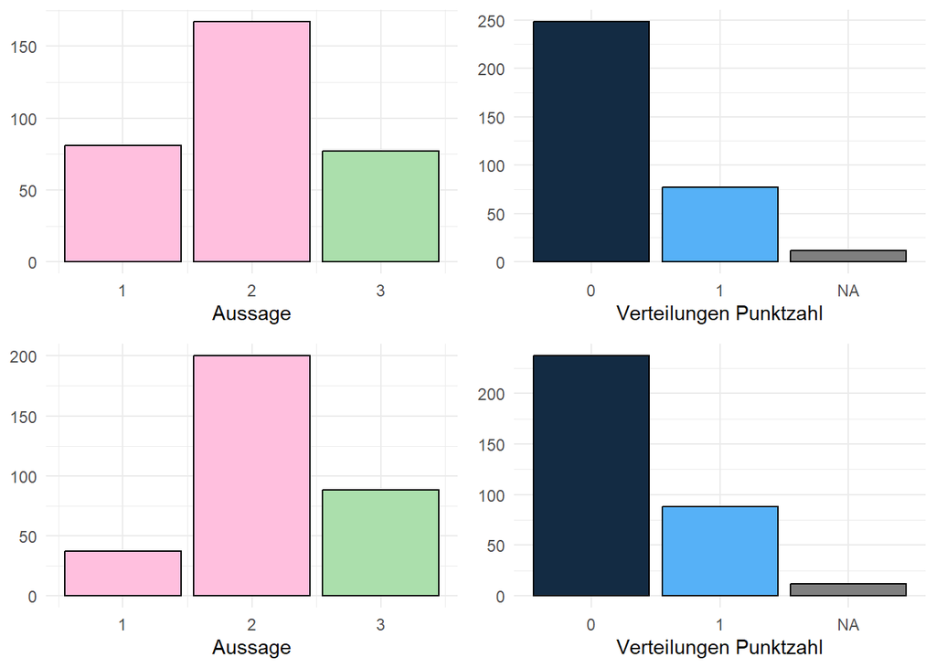

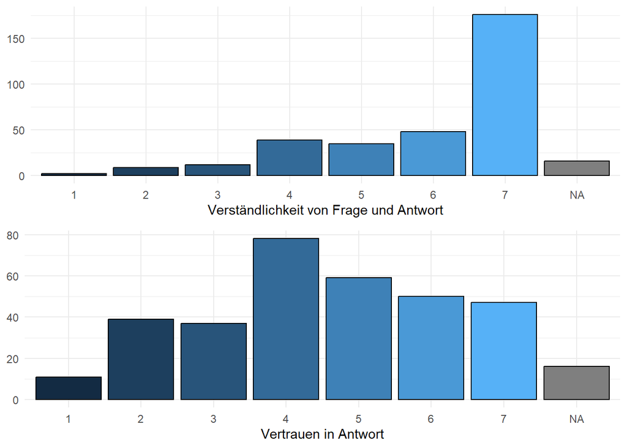

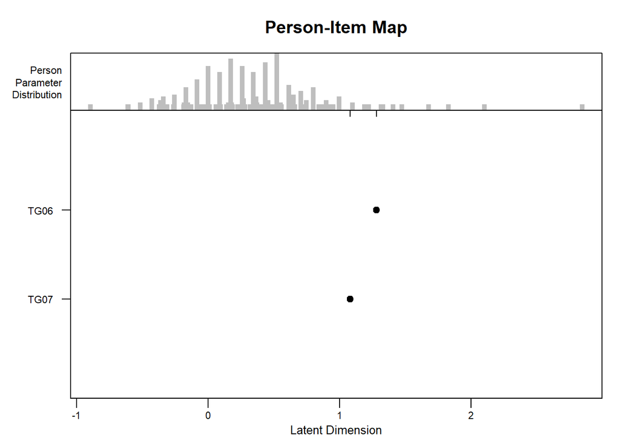

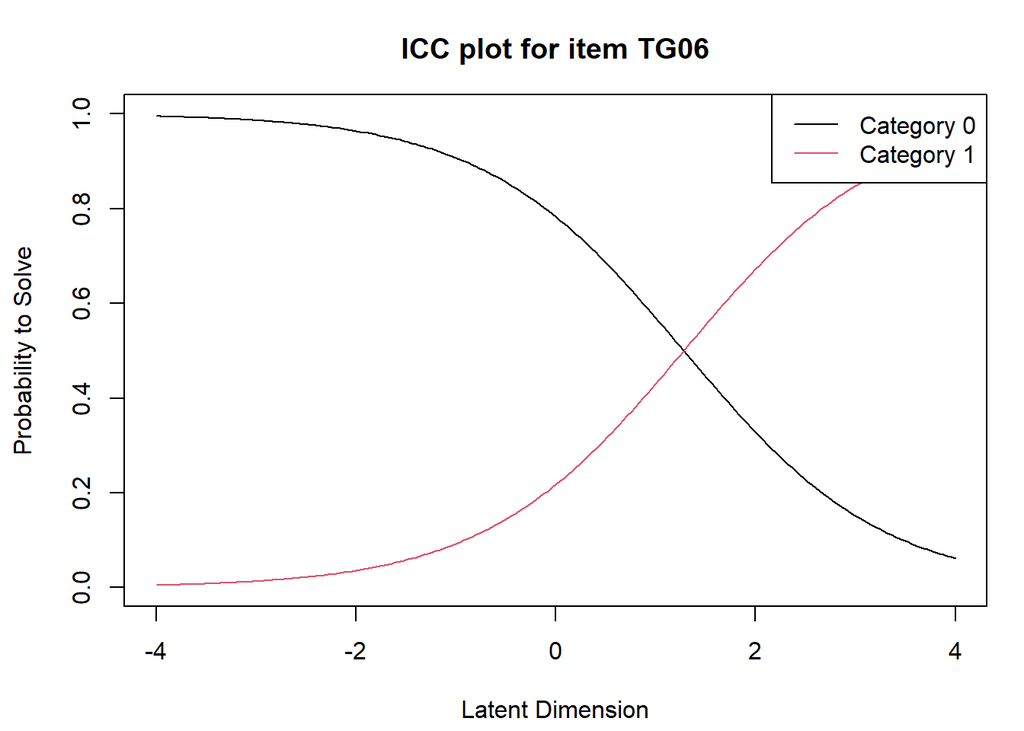

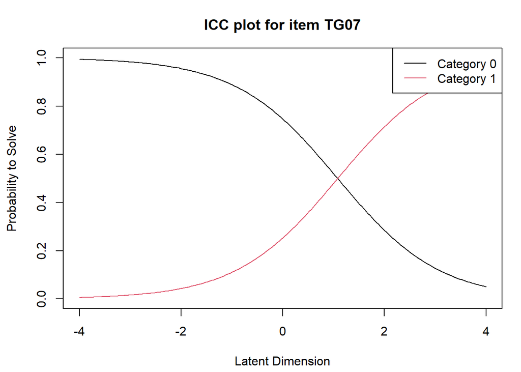

- **Inhalt:**
  - FUnktioniert prinzipiell. Da es auch keine größeren Unterschiede zwischen den Fragen gibt, könnte man auch den zweiten Teil weglassen und nur den zum grammatikalisch korrekten Satz behalten, da dieser auch eindeutig ist.

  **Verständnis**
  - Wird als sehr verständlich empfunden

#### Zeitpunkt

| **Zeitpunkt** | Der ML-Workflow unterscheidet zwischen der Erstellung/Verbesserung und der Anwendung von ML-Modellen. Während der Erstellung/Verbesserung lernt das Modell und passt sich strukturell an. Wird das Model… |
| --- | --- |

| Frage | average | avrg_percentage | max_points |
| --- | --- | --- | --- |
| TG09 | 1.77 | 0.44 | 4 |

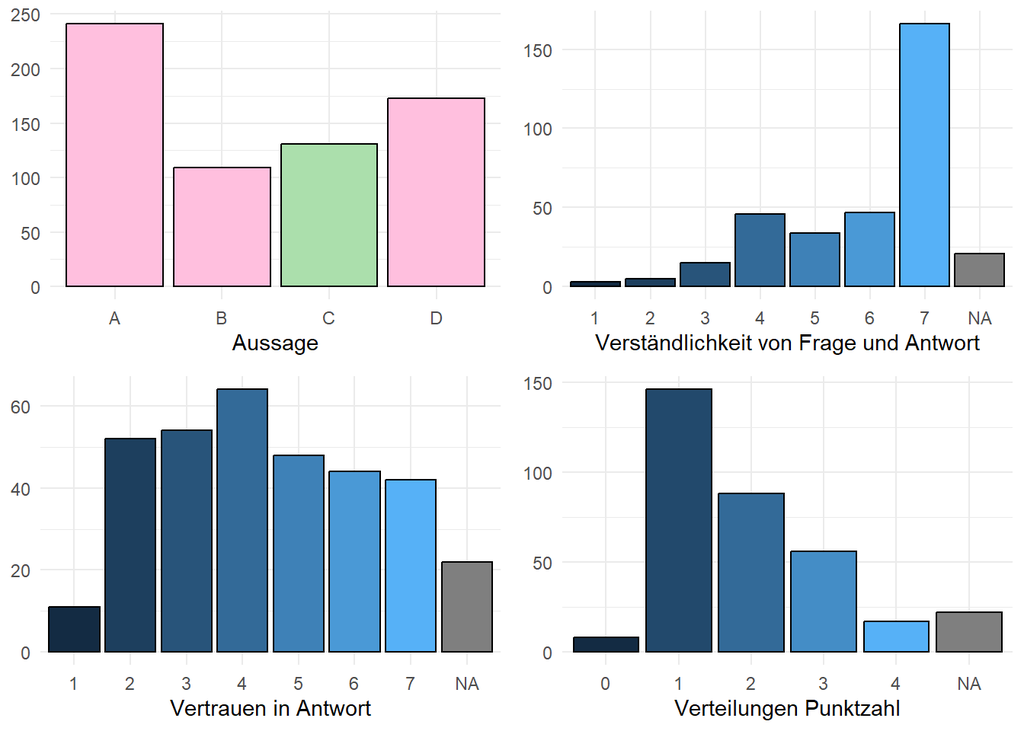

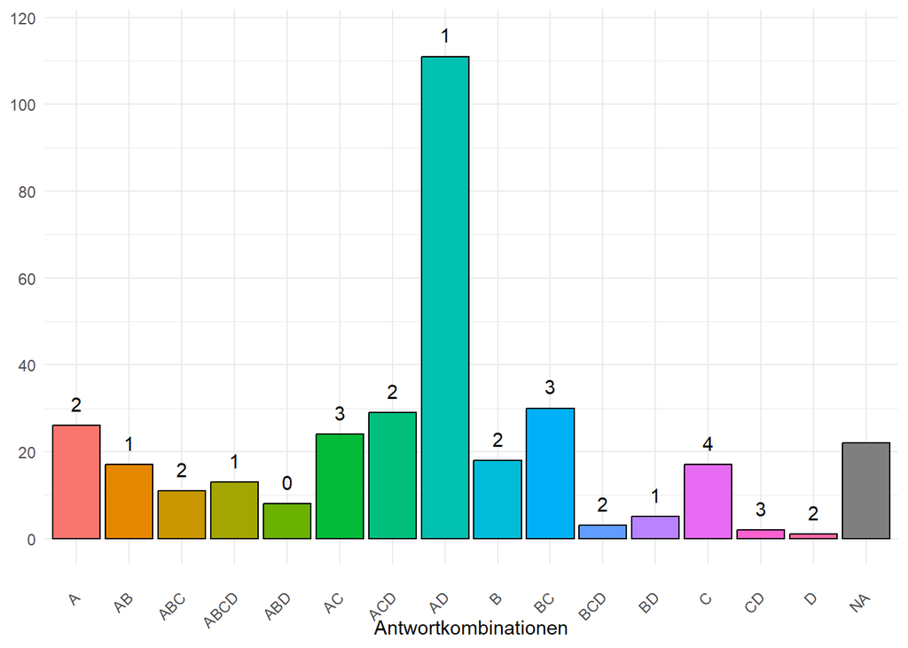

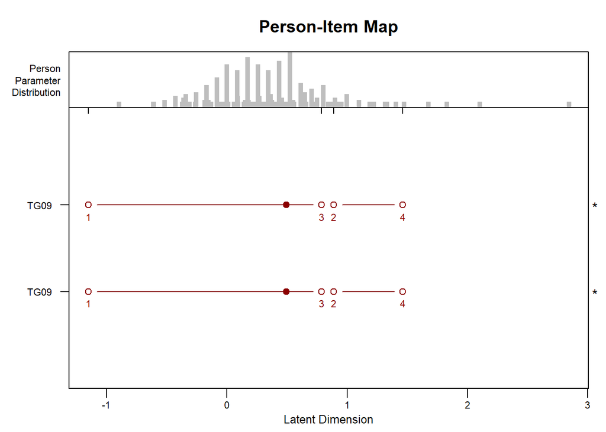

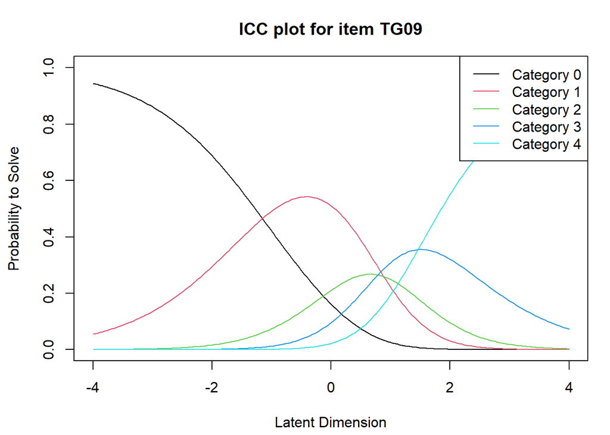

- **Inhalt:**
  - Knappe Schwellentausch bei 2 und 3
  - Problem könnte hier sein, dass man entweder Kategorie A+D oder B+C wählt, weil **besser** oder **genauso gut**
  - Hält Leute aber nicht davon ab, auch kombiniert anzukreuzen, was eigentlich keinen Sinn macht
  - Vielleicht in der Formulierung aufweichen?
  - Eventuell nur falsche Aussagen?

  **Verständnis**
  - Wird größtenteils als verständlich empfunden, mit vereinzelten Irritationen

#### Programmierung

| **Programmierung** | Die Entwickler programmieren die Struktur und die Art des Trainings. Dazu zählen die Modellstruktur und das Lernverfahren. Nicht programmiert werden die Verarbeitungsregeln des Modells. |
| --- | --- |

| Frage | average | avrg_percentage | max_points |
| --- | --- | --- | --- |
| TG11 | 2.22 | 0.44 | 5 |

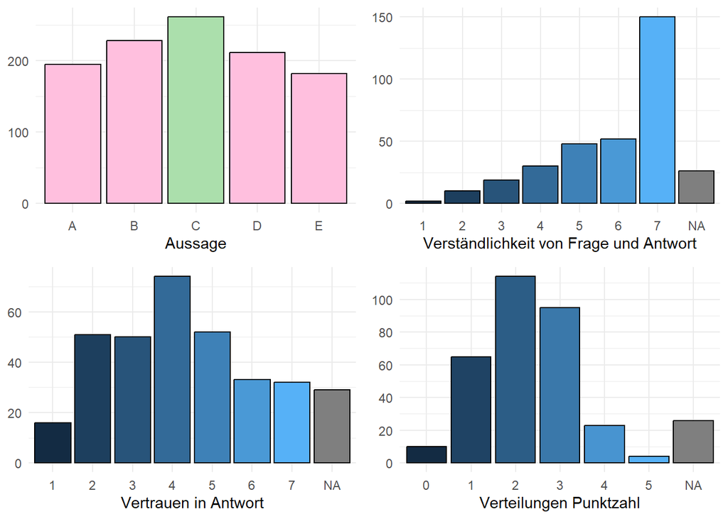

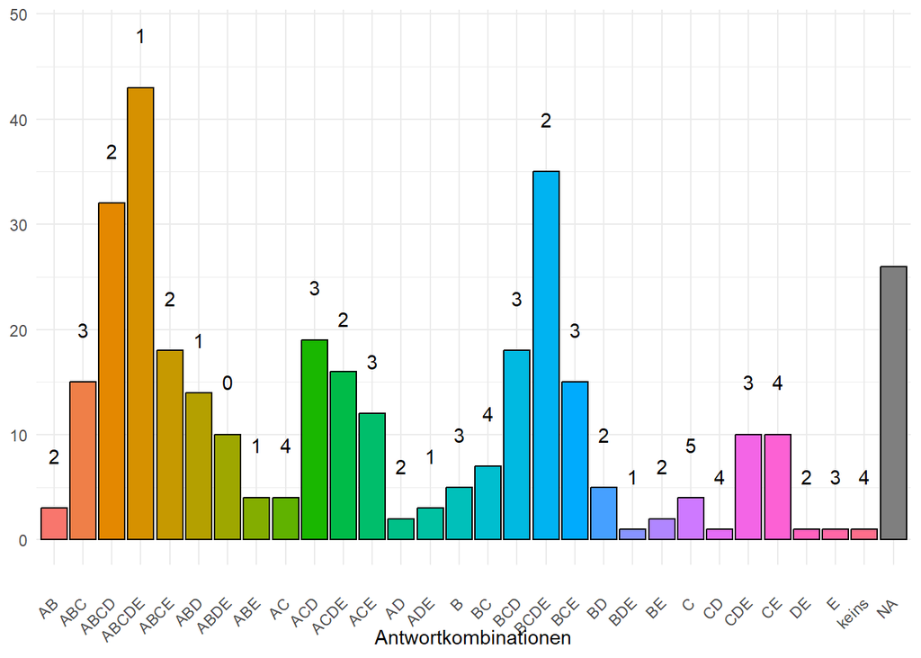

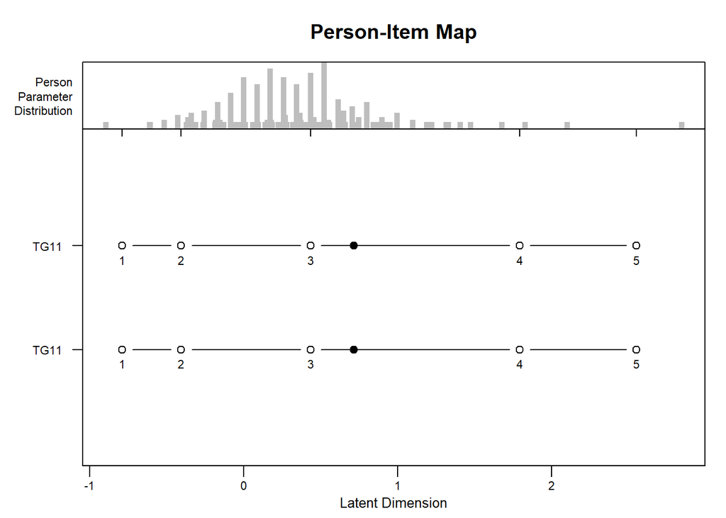

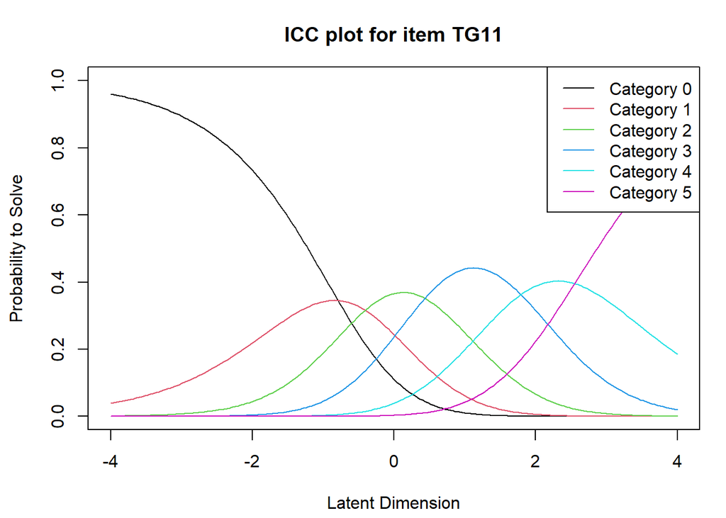

- **Inhalt:**
  - sehr gut funktionierendes Item
  - Schwellen 1 und 5 sind zu leicht bzw. schwer, aber ich sehe nicht, wie man das wirklich verbessern kann

  **Verständnis**
  - Wird größtenteils als verständlich empfunden